# Walmart Sales Analysis (EDA)

**Objective:** Analyze Walmart's weekly sales data to identify seasonal trends, measure the impact of holidays, determine top-performing stores, and examine correlations with external factors such as fuel price, CPI, and unemployment rate.

**Objective:** วิเคราะห์ข้อมูลยอดขายรายสัปดาห์ของ Walmart เพื่อหาแนวโน้มตามฤดูกาล (seasonality), ผลของช่วงเทศกาล (holiday impact), ร้านที่ทำผลงานดีที่สุด (top stores) และความสัมพันธ์กับตัวแปรภายนอก (เช่น Fuel Price, CPI, Unemployment)

## 1) Setup & Imports

```python
import pandas as pd
import numpy as np
import matplotlib.pyplot as plt

# (Optional) ถ้ามี seaborn แนะนำให้ใช้เพื่อกราฟสวยขึ้น
try:
    import seaborn as sns
    sns.set(style="whitegrid")
except Exception:
    sns = None
    pass

pd.set_option('display.float_format', lambda x: f'{x:,.2f}')
```

## 2) Load Dataset

- Update the variable DATA_PATH to point to your CSV file.
- Then, run this cell to load the dataset and display the first five rows.
- แก้ไขตัวแปร `DATA_PATH` ให้ชี้ไปที่ไฟล์ CSV ของคุณ
- จากนั้นรันเซลล์นี้เพื่อโหลดข้อมูลและดู 5 แถวแรก

```python
# >>> เปลี่ยนพาธไฟล์ตามจริงของคุณ <<<
DATA_PATH = r"S:\BusinessAnalyticProject\Walmart_Sales.csv"

df = pd.read_csv(DATA_PATH)
df.head()
```

|  | Store | Date | Weekly_Sales | Holiday_Flag | Temperature | Fuel_Price | CPI | Unemployment |
| --- | --- | --- | --- | --- | --- | --- | --- | --- |
| 0 | 1 | 05-02-2010 | 1,643,690.90 | 0 | 42.31 | 2.57 | 211.10 | 8.11 |
| 1 | 1 | 12-02-2010 | 1,641,957.44 | 1 | 38.51 | 2.55 | 211.24 | 8.11 |
| 2 | 1 | 19-02-2010 | 1,611,968.17 | 0 | 39.93 | 2.51 | 211.29 | 8.11 |
| 3 | 1 | 26-02-2010 | 1,409,727.59 | 0 | 46.63 | 2.56 | 211.32 | 8.11 |
| 4 | 1 | 05-03-2010 | 1,554,806.68 | 0 | 46.50 | 2.62 | 211.35 | 8.11 |

## 3) Initial Data Checks

Check the basic structure of the dataset: size, data types, summary statistics, and missing values.

ตรวจสอบโครงสร้างข้อมูลเบื้องต้น: ขนาดข้อมูล, ชนิดข้อมูล, สถิติสรุป, และ missing values

```python
print("Shape:", df.shape)
display(df.info())
display(df.describe(include='all'))
print("\nMissing values per column:")
print(df.isnull().sum())
```

```
Shape: (6435, 8)
<class 'pandas.core.frame.DataFrame'>
RangeIndex: 6435 entries, 0 to 6434
Data columns (total 8 columns):
 #   Column        Non-Null Count  Dtype
---  ------        --------------  -----
 0   Store         6435 non-null   int64
 1   Date          6435 non-null   object
 2   Weekly_Sales  6435 non-null   float64
 3   Holiday_Flag  6435 non-null   int64
 4   Temperature   6435 non-null   float64
 5   Fuel_Price    6435 non-null   float64
 6   CPI           6435 non-null   float64
 7   Unemployment  6435 non-null   float64
dtypes: float64(5), int64(2), object(1)
memory usage: 402.3+ KB
```

```
None
```

|  | Store | Date | Weekly_Sales | Holiday_Flag | Temperature | Fuel_Price | CPI | Unemployment |
| --- | --- | --- | --- | --- | --- | --- | --- | --- |
| count | 6,435.00 | 6435 | 6,435.00 | 6,435.00 | 6,435.00 | 6,435.00 | 6,435.00 | 6,435.00 |
| unique | NaN | 143 | NaN | NaN | NaN | NaN | NaN | NaN |
| top | NaN | 05-02-2010 | NaN | NaN | NaN | NaN | NaN | NaN |
| freq | NaN | 45 | NaN | NaN | NaN | NaN | NaN | NaN |
| mean | 23.00 | NaN | 1,046,964.88 | 0.07 | 60.66 | 3.36 | 171.58 | 8.00 |
| std | 12.99 | NaN | 564,366.62 | 0.26 | 18.44 | 0.46 | 39.36 | 1.88 |
| min | 1.00 | NaN | 209,986.25 | 0.00 | -2.06 | 2.47 | 126.06 | 3.88 |
| 25% | 12.00 | NaN | 553,350.10 | 0.00 | 47.46 | 2.93 | 131.74 | 6.89 |
| 50% | 23.00 | NaN | 960,746.04 | 0.00 | 62.67 | 3.44 | 182.62 | 7.87 |
| 75% | 34.00 | NaN | 1,420,158.66 | 0.00 | 74.94 | 3.73 | 212.74 | 8.62 |
| max | 45.00 | NaN | 3,818,686.45 | 1.00 | 100.14 | 4.47 | 227.23 | 14.31 |

```
Missing values per column:
Store           0
Date            0
Weekly_Sales    0
Holiday_Flag    0
Temperature     0
Fuel_Price      0
CPI             0
Unemployment    0
dtype: int64
```

## 4) Data Preparation (Date → datetime, New Columns)

- Convert the `Date` column from *object* to `datetime`.
- Create new columns: `Year` and `Month`.
- แปลง `Date` จาก object เป็น `datetime`
- สร้างคอลัมน์ `Year` และ `Month`

```python
# ถ้าข้อมูลวัน/เดือน/ปี เช่น 05-02-2010 ให้ใช้ dayfirst=True หรือระบุ format='%d-%m-%Y'
try:
    df['Date'] = pd.to_datetime(df['Date'], format='%d-%m-%Y')
except Exception:
    df['Date'] = pd.to_datetime(df['Date'], dayfirst=True, errors='coerce')

df['Year'] = df['Date'].dt.year
df['Month'] = df['Date'].dt.month

df[['Date', 'Year', 'Month']].head()
```

|  | Date | Year | Month |
| --- | --- | --- | --- |
| 0 | 2010-02-05 | 2010 | 2 |
| 1 | 2010-02-12 | 2010 | 2 |
| 2 | 2010-02-19 | 2010 | 2 |
| 3 | 2010-02-26 | 2010 | 2 |
| 4 | 2010-03-05 | 2010 | 3 |

## 5) Duplicates Check

- Check for duplicate rows and remove them if necessary.
- ตรวจสอบแถวข้อมูลซ้ำ และลบออกถ้าจำเป็น

```python
dups = df.duplicated().sum()
print(f"Duplicate rows: {dups}")
# ถ้าต้องการลบข้อมูลซ้ำ ให้ uncomment บรรทัดด้านล่าง
# df = df.drop_duplicates().copy()
```

```
Duplicate rows: 0
```

## 6) EDA — Trend of Total Weekly Sales Over Time

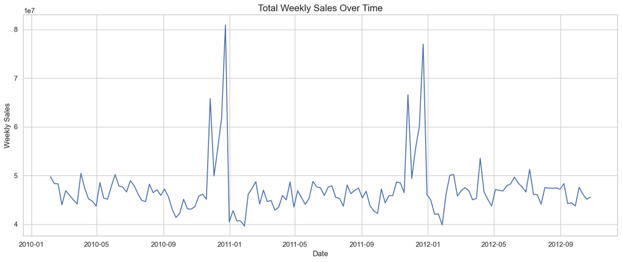

```python
sales_trend = df.groupby('Date')['Weekly_Sales'].sum().reset_index()

plt.figure(figsize=(14,6))
plt.plot(sales_trend['Date'], sales_trend['Weekly_Sales'])
plt.title('Total Weekly Sales Over Time', fontsize=15)
plt.xlabel('Date'); plt.ylabel('Weekly Sales')
plt.tight_layout(); plt.show()
```

## 7) EDA — Holiday vs Non-Holiday Sales

(The dataset must include a `Holiday_Flag` column, where `1` indicates a holiday week.)

(ต้องมีคอลัมน์ `Holiday_Flag` = 1 สำหรับสัปดาห์เทศกาล)

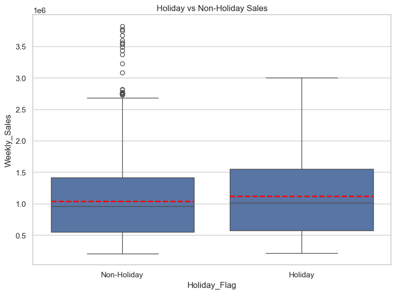

```python
if 'Holiday_Flag' in df.columns:
    if sns:
        plt.figure(figsize=(8,6))
        sns.boxplot(data=df, x='Holiday_Flag', y='Weekly_Sales', showmeans=True,
                    meanline=True, meanprops={'color':'red','ls':'--','lw':2})
        plt.title('Holiday vs Non-Holiday Sales')
        plt.xticks([0,1], ['Non-Holiday','Holiday'])
        plt.tight_layout(); plt.show()
    else:
        # matplotlib-only fallback (simple boxplot)
        data_non = df.loc[df['Holiday_Flag']==0, 'Weekly_Sales'].values
        data_hol = df.loc[df['Holiday_Flag']==1, 'Weekly_Sales'].values
        plt.figure(figsize=(8,6))
        plt.boxplot([data_non, data_hol], labels=['Non-Holiday','Holiday'], showmeans=True)
        plt.title('Holiday vs Non-Holiday Sales')
        plt.ylabel('Weekly Sales')
        plt.tight_layout(); plt.show()
else:
    print("Column 'Holiday_Flag' not found in dataset.")
```

## 8) EDA — Top 10 Stores by Average Weekly Sales

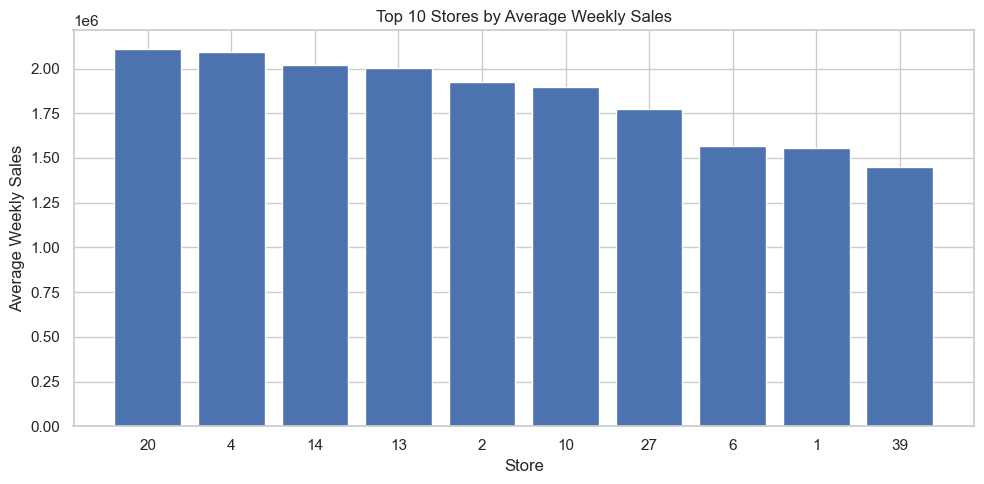

```python
top_stores = (df.groupby('Store')['Weekly_Sales']
                .mean()
                .sort_values(ascending=False)
                .head(10))

plt.figure(figsize=(10,5))
plt.bar(top_stores.index.astype(str), top_stores.values)
plt.title('Top 10 Stores by Average Weekly Sales')
plt.xlabel('Store'); plt.ylabel('Average Weekly Sales')
plt.tight_layout(); plt.show()
```

## 9) Seasonality — Average Weekly Sales by Month (All Years)

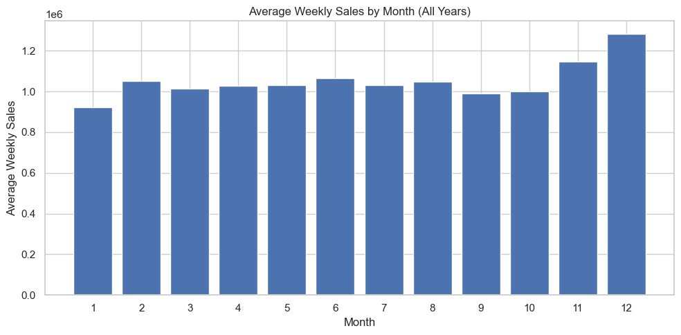

```python
monthly_avg = df.groupby('Month')['Weekly_Sales'].mean().reset_index()

plt.figure(figsize=(10,5))
plt.bar(monthly_avg['Month'].astype(str), monthly_avg['Weekly_Sales'])
plt.title('Average Weekly Sales by Month (All Years)')
plt.xlabel('Month'); plt.ylabel('Average Weekly Sales')
plt.tight_layout(); plt.show()
```

## 10) Seasonality — Monthly Average Sales by Year

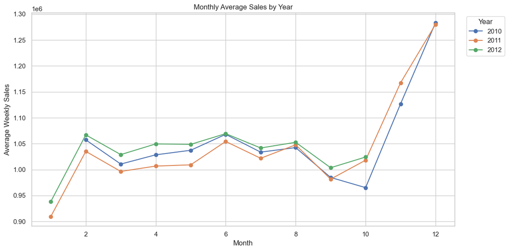

```python
monthly_by_year = (df.groupby(['Year','Month'])['Weekly_Sales']
                     .mean().reset_index())

plt.figure(figsize=(12,6))
for yr, sub in monthly_by_year.groupby('Year'):
    plt.plot(sub['Month'], sub['Weekly_Sales'], marker='o', label=str(yr))
plt.title('Monthly Average Sales by Year')
plt.xlabel('Month'); plt.ylabel('Average Weekly Sales')
plt.legend(title='Year', bbox_to_anchor=(1.02, 1), loc='upper left')
plt.tight_layout(); plt.show()
```

## 11) Correlation Analysis

Analyze the relationships between weekly sales and external factors such as `Temperature`, `Fuel_Price`, `CPI`, and `Unemployment`.

ตรวจสอบความสัมพันธ์ของยอดขายกับตัวแปรภายนอก เช่น `Temperature`, `Fuel_Price`, `CPI`, `Unemployment`

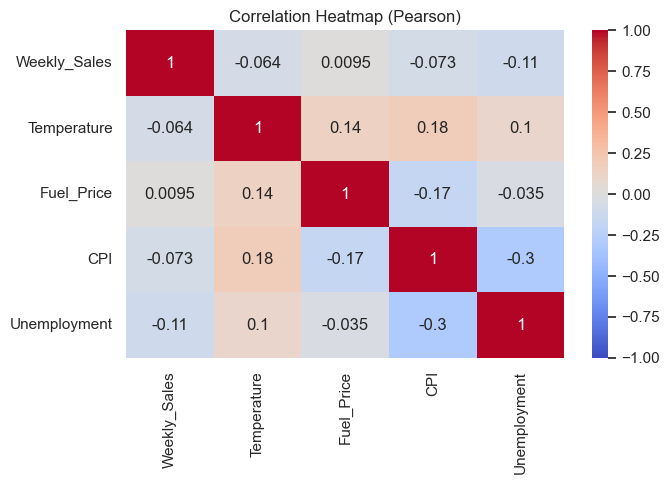

```python
num_cols = ['Weekly_Sales','Temperature','Fuel_Price','CPI','Unemployment']
num_cols = [c for c in num_cols if c in df.columns]
corr = df[num_cols].corr(method='pearson')

plt.figure(figsize=(7,5))
if sns:
    sns.heatmap(corr, annot=True, cmap='coolwarm', vmin=-1, vmax=1)
else:
    im = plt.imshow(corr, cmap='coolwarm', vmin=-1, vmax=1)
    plt.colorbar(im, fraction=0.046, pad=0.04)
    plt.xticks(range(len(num_cols)), num_cols, rotation=45, ha='right')
    plt.yticks(range(len(num_cols)), num_cols)
plt.title('Correlation Heatmap (Pearson)')
plt.tight_layout(); plt.show()
```

## Recommendations:

- Increase inventory and workforce during **holiday seasons (Nov-Dec)**.
- Run promotions during low-season months to boost sales.
- Investigate strategies used by top-performing stores and apply them to lower-performing locations.